# Labor Supply Analysis Using 2016 Canadian Census Data

# Gender-Based Regression Analysis (women)

```r
new_dataset_women <-subset(new_dataset,SEX==1)

Reg_Model_women <- lm(HRSWRK~WAGES+non_labour_INC,data=new_dataset_women)

summary(Reg_Model_women)
```

```
##
## Call:
## lm(formula = HRSWRK ~ WAGES + non_labour_INC, data = new_dataset_women)
##
## Residuals:
##     Min      1Q  Median      3Q     Max
## -74.020 -19.623   1.989  16.396  80.306
##
## Coefficients:
##                 Estimate Std. Error t value Pr(>|t|)
## (Intercept)    1.763e+01  2.010e-01   87.75   <2e-16 ***
## WAGES          6.596e-05  2.188e-06   30.15   <2e-16 ***
## non_labour_INC 6.038e-05  2.130e-06   28.35   <2e-16 ***
## ---
## Signif. codes:  0 '***' 0.001 '**' 0.01 '*' 0.05 '.' 0.1 ' ' 1
##
## Residual standard error: 19.63 on 30344 degrees of freedom
## Multiple R-squared:  0.02911,    Adjusted R-squared:  0.02905
## F-statistic: 454.9 on 2 and 30344 DF,  p-value: < 2.2e-16
```

```r
income_elasticity <-summary(Reg_Model_women)$coefficient[3,1]*mean(new_dataset_women$non_labour_INC)/mean(new_dataset_women$HRSWRK )
income_elasticity
```

```
## [1] 0.1466164
```

```r
substitution_elasticity <-summary(Reg_Model_women)$coefficient[2,1]*mean(new_dataset_women$WAGES)/mean(new_dataset_women$HRSWRK )

substitution_elasticity
```

```
## [1] 0.0695905
```

```r
compensated_elasticity <- substitution_elasticity-(income_elasticity)*(mean(new_dataset_women$WAGES)*mean(new_dataset_women$HRSWRK)/mean(new_dataset_women$non_labour_INC))

compensated_elasticity
```

```
## [1] -1.363572
```

# Gender-Based Regression Analysis (Men)

```r
new_dataset_men <-subset(new_dataset,SEX==2)

Reg_Model_men <- lm(HRSWRK~WAGES+non_labour_INC,data=new_dataset_men)

summary(Reg_Model_men)
```

```
##
## Call:
## lm(formula = HRSWRK ~ WAGES + non_labour_INC, data = new_dataset_men)
##
## Residuals:
##     Min      1Q  Median      3Q     Max
## -88.391 -19.797   5.873  11.504  70.702
##
## Coefficients:
##                 Estimate Std. Error t value Pr(>|t|)
## (Intercept)    2.723e+01  2.398e-01  113.53   <2e-16 ***
## WAGES          7.408e-05  2.440e-06   30.36   <2e-16 ***
## non_labour_INC 6.845e-05  2.469e-06   27.73   <2e-16 ***
## ---
## Signif. codes:  0 '***' 0.001 '**' 0.01 '*' 0.05 '.' 0.1 ' ' 1
##
## Residual standard error: 21.49 on 27736 degrees of freedom
## Multiple R-squared:  0.03259,    Adjusted R-squared:  0.03252
## F-statistic: 467.2 on 2 and 27736 DF,  p-value: < 2.2e-16
```

```r
income_elasticity <-summary(Reg_Model_men)$coefficient[3,1]*mean(new_dataset_men$non_labour_INC)/mean(new_dataset_men$HRSWRK )
income_elasticity
```

```
## [1] 0.08697926
```

```r
substitution_elasticity <-summary(Reg_Model_men)$coefficient[2,1]*mean(new_dataset_men$WAGES)/mean(new_dataset_men$HRSWRK )

substitution_elasticity
```

```
## [1] 0.09214333
```

```r
compensated_elasticity <- substitution_elasticity-(income_elasticity)*(mean(new_dataset_men$WAGES)*mean(new_dataset_men$HRSWRK)/mean(new_dataset_men$non_labour_INC))

compensated_elasticity
```

```
## [1] -2.732148
```

We repeated the same regression model for both men and women separately.Based on the results, women and men are different in terms of income elasticity and compensated elasticity of substitution, while there are almost the same in elasticity of substitution.

# New set of Features

```r
census_2006 <- subset(table, PR==59 &  AGEGRP>=7 & AGEGRP<=16 & CFINC>=1 & CFINC<=28)


census_2006$AGE_SQURE <- census_2006$AGEGRP*census_2006$AGEGRP

new_dataset <- subset(census_2006,select = c("WAGES", "CFINC","HRSWRK","SEX","AGEGRP","PKID0_1","PKID15_24","PKID2_5","PKID25","PKID6_14","MARST","PR","HDGREE","IMMSTAT","ROOM","AGE_SQURE"))


range_f <- c(1000,3500,6000,8500,11000,13500,16000,18500,22500,27500,32500,37500,42500,47500,52500,57500,62500,67500,72500,77500, 85000, 95000,112500, 137500, 162500, 187500, 225000, 250000)

for (i in 1:58086){
  new_dataset$Cfamily_income[i]= range_f[new_dataset$CFINC[i]]
  new_dataset$non_labour_INC[i]=new_dataset$Cfamily_income[i]-new_dataset$WAGES[i]

}
```

Based on the definition of intertemporal elasticity of substitution defined by MaCurdy(1981), the intertemporal substitution effect is interpreted as an elasticity that is associated with a particular kind of parametric wage change. In particular, it determines the response of hours of work at age t to a shift in the age t wage rate holding X or the marginal utility of wealth constant. As a result, we need to introduce the variables showing people background or wage profile. Accordingly, I have considered these variables: Province, Occupation, Census family income groups, education, Investment income, Household income groups, value of the dwelling, TENUR, immigrant status, Generation status, and Aboriginal identity. For part b, we need to define some variables representing people with different wage profile , so age and age-squared can be considered to show the effect of a shift on a wage profile.

# Feature Selection with LASSO

```r
library(glmnet)
x1 <- subset(new_dataset, ROOM<12 & HDGREE<14   & PKID0_1<2 & PKID15_24<2 & PKID2_5<2 & PKID25<2 & PKID6_14<2)
x1$CHILD_NUM <- rowSums(x1[,c("PKID0_1","PKID2_5","PKID6_14","PKID15_24","PKID2_5")],na.rm=TRUE )

y <- as.matrix(subset(x1,select = "HRSWRK"))
x <- as.matrix(subset(x1,select =c("WAGES","non_labour_INC","AGEGRP","MARST","PR","IMMSTAT","ROOM","HDGREE","CHILD_NUM","AGE_SQURE") ))


lassofit <- glmnet(x,y, alpha=1, nlambda=100 )
summary(lassofit)
```

```
##           Length Class     Mode
## a0         80    -none-    numeric
## beta      800    dgCMatrix S4
## df         80    -none-    numeric
## dim         2    -none-    numeric
## lambda     80    -none-    numeric
## dev.ratio  80    -none-    numeric
## nulldev     1    -none-    numeric
## npasses     1    -none-    numeric
## jerr        1    -none-    numeric
## offset      1    -none-    logical
## call        5    -none-    call
## nobs        1    -none-    numeric
```

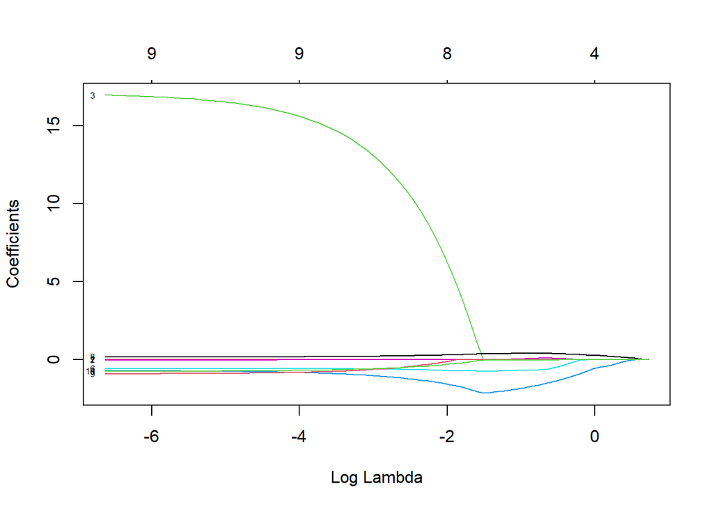

```r
plot(lassofit, xvar ='lambda',label=T )
```

```r
coef(lassofit, s=0.03)
```

```
## 11 x 1 sparse Matrix of class "dgCMatrix"
##                           s1
## (Intercept)    -5.332902e+01
## WAGES           6.859678e-05
## non_labour_INC  6.285298e-05
## AGEGRP          1.468617e+01
## MARST          -8.943035e-01
## PR              .
## IMMSTAT        -5.798172e-01
## ROOM           -3.293553e-04
## HDGREE          2.019713e-01
## CHILD_NUM      -7.433054e-01
## AGE_SQURE      -6.464876e-01
```

Based on the plot,as the lambda increases, more number of variables goes to zero and be excluded from the model. The plot shows age is a key variable and shouldn’t be excluded from the model.

# Cross Validation to Find the Optimal Lambda

After the cross-validation, we found the optimal value for lambda, the result of lasso model based on this optimal value is as follows:

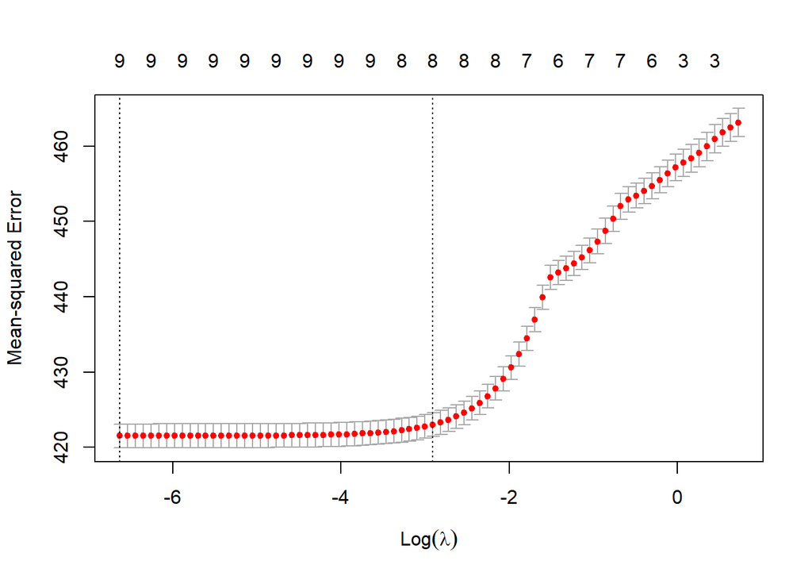

```r
x1 <- subset(new_dataset, ROOM<12 & HDGREE<14   & PKID0_1<2 & PKID15_24<2 & PKID2_5<2 & PKID25<2 & PKID6_14<2)
x1$CHILD_NUM <- rowSums(x1[,c("PKID0_1","PKID2_5","PKID6_14","PKID15_24","PKID2_5")],na.rm=TRUE )

y <- as.matrix(subset(x1,select = "HRSWRK"))
x <- as.matrix(subset(x1,select =c("WAGES","non_labour_INC","AGEGRP","MARST","PR","IMMSTAT","ROOM","HDGREE","CHILD_NUM","AGE_SQURE") ))


cvfit <- cv.glmnet(x, y,type.measure="deviance", alpha=1, nlambda=100)
plot(cvfit)
```

```r
cvfit$lambda.min
```

```
## [1] 0.001321686
```

```r
#coefficients
coef(cvfit, s = "lambda.min")
```

```
## 11 x 1 sparse Matrix of class "dgCMatrix"
##                           s1
## (Intercept)    -6.652827e+01
## WAGES           7.269583e-05
## non_labour_INC  6.708123e-05
## AGEGRP          1.696186e+01
## MARST          -7.138456e-01
## PR              .
## IMMSTAT        -5.594546e-01
## ROOM           -2.296109e-02
## HDGREE          1.724842e-01
## CHILD_NUM      -9.058980e-01
## AGE_SQURE      -7.427203e-01
```

Based on the result, age, number of children, marital status, immigrant status and education affect the labor supply and should be included in the model while the values of wage,province, non-labor income and number of rooms are almost zero, thus they should be excluded from the model.The reason for province is that we already limited our dataset to consider only one province, so the model cannot compare different provinces with each other.

# Regression Analysis on Labor Force Participation Using Linear Probability Model

```r
new_dataset <- subset(census_2006,select = c("WAGES", "CFINC","HRSWRK","SEX","AGEGRP","PKID0_1","PKID15_24","PKID2_5","PKID25","PKID6_14","MARST","PR","HDGREE","IMMSTAT","ROOM","AGE_SQURE","LFACT","INVST","ABOID","KOL"))

range_f <- c(1000,3500,6000,8500,11000,13500,16000,18500,22500,27500,32500,37500,42500,47500,52500,57500,62500,67500,72500,77500, 85000, 95000,112500, 137500, 162500, 187500, 225000, 250000)

for (i in 1:58086){
  new_dataset$Cfamily_income[i]= range_f[new_dataset$CFINC[i]]
  new_dataset$non_labour_INC[i]=new_dataset$Cfamily_income[i]-new_dataset$WAGES[i]

}

new_dataset$dummy_labour <- ifelse(new_dataset$LFACT==1&2,1,0)
new_dataset$CHILD_NUM <- rowSums(new_dataset[,c("PKID0_1","PKID2_5","PKID6_14","PKID15_24","PKID2_5")],na.rm=TRUE )

linear_prb_model <- lm(dummy_labour~WAGES+non_labour_INC+AGEGRP+AGE_SQURE+IMMSTAT+MARST+HDGREE+INVST+ROOM++ABOID+KOL+CHILD_NUM,data=new_dataset)

options("scipen" = 100, "digits"=4)
summary(linear_prb_model )
```

```
##
## Call:
## lm(formula = dummy_labour ~ WAGES + non_labour_INC + AGEGRP +
##     AGE_SQURE + IMMSTAT + MARST + HDGREE + INVST + ROOM + +ABOID +
##     KOL + CHILD_NUM, data = new_dataset)
##
## Residuals:
##    Min     1Q Median     3Q    Max
## -1.947 -0.479  0.202  0.302  1.028
##
## Coefficients:
##                     Estimate    Std. Error t value             Pr(>|t|)
## (Intercept)    -0.7544445684  0.0466656547  -16.17 < 0.0000000000000002 ***
## WAGES           0.0000026407  0.0000000457   57.84 < 0.0000000000000002 ***
## non_labour_INC  0.0000008140  0.0000000396   20.54 < 0.0000000000000002 ***
## AGEGRP          0.2494307506  0.0070540324   35.36 < 0.0000000000000002 ***
## AGE_SQURE      -0.0113647943  0.0002939344  -38.66 < 0.0000000000000002 ***
## IMMSTAT        -0.0166837996  0.0038151134   -4.37    0.000012271813993 ***
## MARST          -0.0020950902  0.0023283056   -0.90                 0.37
## HDGREE          0.0021869694  0.0002895857    7.55    0.000000000000043 ***
## INVST          -0.0000018541  0.0000000458  -40.51 < 0.0000000000000002 ***
## ROOM            0.0012337154  0.0007834509    1.57                 0.12
## ABOID           0.0219644429  0.0019390367   11.33 < 0.0000000000000002 ***
## KOL            -0.0293400228  0.0026253844  -11.18 < 0.0000000000000002 ***
## CHILD_NUM      -0.0028525470  0.0006852195   -4.16    0.000031458974100 ***
## ---
## Signif. codes:  0 '***' 0.001 '**' 0.01 '*' 0.05 '.' 0.1 ' ' 1
##
## Residual standard error: 0.428 on 58073 degrees of freedom
## Multiple R-squared:  0.109,  Adjusted R-squared:  0.109
## F-statistic:  591 on 12 and 58073 DF,  p-value: <0.0000000000000002
```

# Regression Analysis on Labor Force Participation Using Probit Model

```r
myprobit <- glm(dummy_labour~WAGES+non_labour_INC+AGEGRP+AGE_SQURE+IMMSTAT+MARST+HDGREE+INVST+ROOM++ABOID+KOL+CHILD_NUM, family = binomial(link = "probit"), data=new_dataset)

summary(myprobit)
```

```
##
## Call:
## glm(formula = dummy_labour ~ WAGES + non_labour_INC + AGEGRP +
##     AGE_SQURE + IMMSTAT + MARST + HDGREE + INVST + ROOM + +ABOID +
##     KOL + CHILD_NUM, family = binomial(link = "probit"), data = new_dataset)
##
## Coefficients:
##                    Estimate   Std. Error z value             Pr(>|z|)
## (Intercept)    -3.483143014  0.147540371  -23.61 < 0.0000000000000002 ***
## WAGES           0.000013202  0.000000242   54.54 < 0.0000000000000002 ***
## non_labour_INC  0.000002377  0.000000134   17.71 < 0.0000000000000002 ***
## AGEGRP          0.663398288  0.022389530   29.63 < 0.0000000000000002 ***
## AGE_SQURE      -0.030382147  0.000933936  -32.53 < 0.0000000000000002 ***
## IMMSTAT        -0.031344400  0.012319776   -2.54              0.01095 *
## MARST          -0.001207119  0.007548991   -0.16              0.87296
## HDGREE          0.007682414  0.001082514    7.10      0.0000000000013 ***
## INVST          -0.000010860  0.000000247  -44.01 < 0.0000000000000002 ***
## ROOM            0.005895683  0.002536993    2.32              0.02013 *
## ABOID           0.059014527  0.005919525    9.97 < 0.0000000000000002 ***
## KOL            -0.076210898  0.008208802   -9.28 < 0.0000000000000002 ***
## CHILD_NUM      -0.007841309  0.002135369   -3.67              0.00024 ***
## ---
## Signif. codes:  0 '***' 0.001 '**' 0.01 '*' 0.05 '.' 0.1 ' ' 1
##
## (Dispersion parameter for binomial family taken to be 1)
##
##     Null deviance: 69883  on 58085  degrees of freedom
## Residual deviance: 61971  on 58073  degrees of freedom
## AIC: 61997
##
## Number of Fisher Scoring iterations: 11
```

# Gender-Based Probit Model Analysis (women)

```r
new_dataset$SEX <- census_2006$SEX
new_dataset_women <-subset(new_dataset,SEX==1)

myprobit_WOMEN <- glm(dummy_labour~WAGES+non_labour_INC+AGEGRP+AGE_SQURE+IMMSTAT+MARST+HDGREE+INVST+ROOM++ABOID+KOL+CHILD_NUM, family = binomial(link = "probit"), data=new_dataset_women)

summary(myprobit_WOMEN )
```

```
##
## Call:
## glm(formula = dummy_labour ~ WAGES + non_labour_INC + AGEGRP +
##     AGE_SQURE + IMMSTAT + MARST + HDGREE + INVST + ROOM + +ABOID +
##     KOL + CHILD_NUM, family = binomial(link = "probit"), data = new_dataset_women)
##
## Coefficients:
##                    Estimate   Std. Error z value             Pr(>|z|)
## (Intercept)    -2.810679752  0.201501822  -13.95 < 0.0000000000000002 ***
## WAGES           0.000021172  0.000000431   49.11 < 0.0000000000000002 ***
## non_labour_INC  0.000001922  0.000000178   10.77 < 0.0000000000000002 ***
## AGEGRP          0.501814080  0.031024502   16.17 < 0.0000000000000002 ***
## AGE_SQURE      -0.023658340  0.001300344  -18.19 < 0.0000000000000002 ***
## IMMSTAT        -0.055058392  0.016562719   -3.32              0.00089 ***
## MARST           0.053042952  0.009853369    5.38      0.0000000731609 ***
## HDGREE          0.005465221  0.001507560    3.63              0.00029 ***
## INVST          -0.000019254  0.000000444  -43.39 < 0.0000000000000002 ***
## ROOM            0.007512061  0.003451149    2.18              0.02950 *
## ABOID           0.053039380  0.007868837    6.74      0.0000000000158 ***
## KOL            -0.076806928  0.010806959   -7.11      0.0000000000012 ***
## CHILD_NUM      -0.011441185  0.002749338   -4.16      0.0000316256577 ***
## ---
## Signif. codes:  0 '***' 0.001 '**' 0.01 '*' 0.05 '.' 0.1 ' ' 1
##
## (Dispersion parameter for binomial family taken to be 1)
##
##     Null deviance: 39177  on 30346  degrees of freedom
## Residual deviance: 33994  on 30334  degrees of freedom
## AIC: 34020
##
## Number of Fisher Scoring iterations: 7
```

# Gender-Based Probit Model Analysis (Men)

```r
new_dataset$SEX <- census_2006$SEX
new_dataset_men <-subset(new_dataset,SEX==2)

myprobit_MEN <- glm(dummy_labour~WAGES+non_labour_INC+AGEGRP+AGE_SQURE+IMMSTAT+MARST+HDGREE+INVST+ROOM++ABOID+KOL+CHILD_NUM, family = binomial(link = "probit"), data=new_dataset_men)

summary(myprobit_MEN )
```

```
##
## Call:
## glm(formula = dummy_labour ~ WAGES + non_labour_INC + AGEGRP +
##     AGE_SQURE + IMMSTAT + MARST + HDGREE + INVST + ROOM + +ABOID +
##     KOL + CHILD_NUM, family = binomial(link = "probit"), data = new_dataset_men)
##
## Coefficients:
##                    Estimate   Std. Error z value             Pr(>|z|)
## (Intercept)    -4.263069060  0.222614887  -19.15 < 0.0000000000000002 ***
## WAGES           0.000008815  0.000000303   29.05 < 0.0000000000000002 ***
## non_labour_INC  0.000003222  0.000000212   15.23 < 0.0000000000000002 ***
## AGEGRP          0.889018748  0.033245240   26.74 < 0.0000000000000002 ***
## AGE_SQURE      -0.040335278  0.001382723  -29.17 < 0.0000000000000002 ***
## IMMSTAT        -0.008421851  0.019018992   -0.44                 0.66
## MARST          -0.117576722  0.012291283   -9.57 < 0.0000000000000002 ***
## HDGREE          0.007458302  0.001592539    4.68      0.0000028232297 ***
## INVST          -0.000005681  0.000000304  -18.70 < 0.0000000000000002 ***
## ROOM            0.005616767  0.003863710    1.45                 0.15
## ABOID           0.063512452  0.009171620    6.92      0.0000000000044 ***
## KOL            -0.063023126  0.013132943   -4.80      0.0000015957311 ***
## CHILD_NUM       0.006341670  0.004144913    1.53                 0.13
## ---
## Signif. codes:  0 '***' 0.001 '**' 0.01 '*' 0.05 '.' 0.1 ' ' 1
##
## (Dispersion parameter for binomial family taken to be 1)
##
##     Null deviance: 29674  on 27738  degrees of freedom
## Residual deviance: 26289  on 27726  degrees of freedom
## AIC: 26315
##
## Number of Fisher Scoring iterations: 6
```